# ExtraaLearn Project

## Context

The EdTech industry has been surging in the past decade immensely, and according to a forecast, the Online Education market would be worth $286.62bn by 2023 with a compound annual growth rate (CAGR) of 10.26% from 2018 to 2023. The modern era of online education has enforced a lot in its growth and expansion beyond any limit. Due to having many dominant features like ease of information sharing, personalized learning experience, transparency of assessment, etc, it is now preferable to traditional education.

In the present scenario due to the Covid-19, the online education sector has witnessed rapid growth and is attracting a lot of new customers. Due to this rapid growth, many new companies have emerged in this industry. With the availability and ease of use of digital marketing resources, companies can reach out to a wider audience with their offerings. The customers who show interest in these offerings are termed as leads. There are various sources of obtaining leads for Edtech companies, like

- The customer interacts with the marketing front on social media or other online platforms.
- The customer browses the website/app and downloads the brochure
- The customer connects through emails for more information.

The company then nurtures these leads and tries to convert them to paid customers. For this, the representative from the organization connects with the lead on call or through email to share further details.

## Objective

ExtraaLearn is an initial stage startup that offers programs on cutting-edge technologies to students and professionals to help them upskill/reskill. With a large number of leads being generated on a regular basis, one of the issues faced by ExtraaLearn is to identify which of the leads are more likely to convert so that they can allocate resources accordingly. You, as a data scientist at ExtraaLearn, have been provided the leads data to:

- Analyze and build an ML model to help identify which leads are more likely to convert to paid customers,
- Find the factors driving the lead conversion process
- Create a profile of the leads which are likely to convert

## Data Description

The data contains the different attributes of leads and their interaction details with ExtraaLearn. The detailed data dictionary is given below.

**Data Dictionary**

- ID: ID of the lead
- age: Age of the lead
- current_occupation: Current occupation of the lead. Values include 'Professional','Unemployed',and 'Student'
- first_interaction: How did the lead first interacted with ExtraaLearn. Values include 'Website', 'Mobile App'
- profile_completed: What percentage of profile has been filled by the lead on the website/mobile app. Values include Low - (0-50%), Medium - (50-75%), High (75-100%)
- website_visits: How many times has a lead visited the website
- time_spent_on_website: Total time spent on the website
- page_views_per_visit: Average number of pages on the website viewed during the visits.
- last_activity: Last interaction between the lead and ExtraaLearn.
  - Email Activity: Seeking for details about program through email, Representative shared information with lead like brochure of program , etc
  - Phone Activity: Had a Phone Conversation with representative, Had conversation over SMS with representative, etc
  - Website Activity: Interacted on live chat with representative, Updated profile on website, etc
- print_media_type1: Flag indicating whether the lead had seen the ad of ExtraaLearn in the Newspaper.
- print_media_type2: Flag indicating whether the lead had seen the ad of ExtraaLearn in the Magazine.
- digital_media: Flag indicating whether the lead had seen the ad of ExtraaLearn on the digital platforms.
- educational_channels: Flag indicating whether the lead had heard about ExtraaLearn in the education channels like online forums, discussion threads, educational websites, etc.
- referral: Flag indicating whether the lead had heard about ExtraaLearn through reference.
- status: Flag indicating whether the lead was converted to a paid customer or not.

## Importing necessary libraries and data

```python
import pandas as pd
import numpy as np

import warnings
warnings.filterwarnings('ignore')

import matplotlib.pyplot as plt
import seaborn as sns

from sklearn.model_selection import train_test_split
from sklearn.preprocessing import StandardScaler
# Metrics to evaluate the model
from sklearn import metrics
from sklearn.metrics import confusion_matrix, classification_report, precision_recall_curve,recall_score
from sklearn import tree


# For tuning the model
from sklearn.model_selection import GridSearchCV

# To ignore warnings
import warnings
warnings.filterwarnings("ignore")
```

```python
import seaborn as sns
import matplotlib.pyplot as plt

# Set style
sns.set_style("whitegrid") # You can use other styles like "darkgrid", "white", "dark", "ticks"

# Set color palette
sns.set_palette("muted") # You can use other palettes like "pastel" "deep", "muted", "colorblind", etc.
```

```python
from sklearn.model_selection import train_test_split
from sklearn.tree import DecisionTreeClassifier
from sklearn.metrics import classification_report, accuracy_score
from sklearn.ensemble import RandomForestClassifier
```

## Data Overview

- Observations
- Sanity checks

```python
dt = pd.read_csv('ExtraaLearn.csv')
```

```python
dt.head()
```

|  | ID | age | current_occupation | first_interaction | profile_completed | website_visits | time_spent_on_website | page_views_per_visit | last_activity | print_media_type1 | print_media_type2 | digital_media | educational_channels | referral | status |
| --- | --- | --- | --- | --- | --- | --- | --- | --- | --- | --- | --- | --- | --- | --- | --- |
| 0 | EXT001 | 57 | Unemployed | Website | High | 7 | 1639 | 1.861 | Website Activity | Yes | No | Yes | No | No | 1 |
| 1 | EXT002 | 56 | Professional | Mobile App | Medium | 2 | 83 | 0.320 | Website Activity | No | No | No | Yes | No | 0 |
| 2 | EXT003 | 52 | Professional | Website | Medium | 3 | 330 | 0.074 | Website Activity | No | No | Yes | No | No | 0 |
| 3 | EXT004 | 53 | Unemployed | Website | High | 4 | 464 | 2.057 | Website Activity | No | No | No | No | No | 1 |
| 4 | EXT005 | 23 | Student | Website | High | 4 | 600 | 16.914 | Email Activity | No | No | No | No | No | 0 |

```python
dt.shape
```

```
(4612, 15)
```

Dataset has 4612 rows and 15 columns.

```python
dt.info()
```

```
<class 'pandas.core.frame.DataFrame'>
RangeIndex: 4612 entries, 0 to 4611
Data columns (total 15 columns):
 #   Column                 Non-Null Count  Dtype
---  ------                 --------------  -----
 0   ID                     4612 non-null   object
 1   age                    4612 non-null   int64
 2   current_occupation     4612 non-null   object
 3   first_interaction      4612 non-null   object
 4   profile_completed      4612 non-null   object
 5   website_visits         4612 non-null   int64
 6   time_spent_on_website  4612 non-null   int64
 7   page_views_per_visit   4612 non-null   float64
 8   last_activity          4612 non-null   object
 9   print_media_type1      4612 non-null   object
 10  print_media_type2      4612 non-null   object
 11  digital_media          4612 non-null   object
 12  educational_channels   4612 non-null   object
 13  referral               4612 non-null   object
 14  status                 4612 non-null   int64
dtypes: float64(1), int64(4), object(10)
memory usage: 540.6+ KB
```

Dataset has 4612 rows and 15 columns. Object type columns are ID, current_occupation, first_interaction, profile_complete, last_activity, print_media_type1, print_media_type2, digital_media, educational_channels, referral. Integer type of data columns : age, website_visits, time_spent_on_website, status. Float type is page_views_per_visit. No missing value.

**Let's check the unique values in each column**

```python
dt.nunique()
```

```
ID                       4612
age                        46
current_occupation          3
first_interaction           2
profile_completed           3
website_visits             27
time_spent_on_website    1623
page_views_per_visit     2414
last_activity               3
print_media_type1           2
print_media_type2           2
digital_media               2
educational_channels        2
referral                    2
status                      2
dtype: int64
```

**Observations:**

- **ID** which is unique for each leads and **we can drop this column** as it would not add any value to our analysis.
- On the basis of number of unique values in each column and the data description, we can identify the continuous and categorical columns in the data.

**Let's drop the column mentioned above** and define lists for numerical and categorical columns to explore them separately.

```python
# Dropping the columns
dt=dt.drop(['ID'],axis=1)
```

## Exploratory Data Analysis (EDA)

- EDA is an important part of any project involving data.
- It is important to investigate and understand the data better before building a model with it.
- A few questions have been mentioned below which will help you approach the analysis in the right manner and generate insights from the data.
- A thorough analysis of the data, in addition to the questions mentioned below, should be done.

**Questions**

1. Leads will have different expectations from the outcome of the course and the current occupation may play a key role in getting them to participate in the program. Find out how current occupation affects lead status.
2. The company's first impression on the customer must have an impact. Do the first channels of interaction have an impact on the lead status?
3. The company uses multiple modes to interact with prospects. Which way of interaction works best?
4. The company gets leads from various channels such as print media, digital media, referrals, etc. Which of these channels have the highest lead conversion rate?
5. People browsing the website or mobile application are generally required to create a profile by sharing their personal data before they can access additional information.Does having more details about a prospect increase the chances of conversion?

```python
# Creating numerical columns
num_cols=['age','website_visits','time_spent_on_website','page_views_per_visit']

# Creating categorical variables
cat_cols= ['current_occupation','first_interaction','profile_completed', 'last_activity','print_media_type1', 'print_media_type2','digital_media','educational_channels','referral',
           'status']
```

The 'status' feature has data of numerical type (int64), but the meaning of this data is categorical; it takes on a value of either "1" or "0," indicating whether the lead was converted to a paid customer or not.

### **Univariate analysis of numerical columns**

```python
# Checking summary statistics
dt[num_cols].describe().T
```

|  | count | mean | std | min | 25% | 50% | 75% | max |
| --- | --- | --- | --- | --- | --- | --- | --- | --- |
| age | 4612.0 | 46.201214 | 13.161454 | 18.0 | 36.00000 | 51.000 | 57.00000 | 63.000 |
| website_visits | 4612.0 | 3.566782 | 2.829134 | 0.0 | 2.00000 | 3.000 | 5.00000 | 30.000 |
| time_spent_on_website | 4612.0 | 724.011275 | 743.828683 | 0.0 | 148.75000 | 376.000 | 1336.75000 | 2537.000 |
| page_views_per_visit | 4612.0 | 3.026126 | 1.968125 | 0.0 | 2.07775 | 2.792 | 3.75625 | 18.434 |

**Observations:**

The data represents a sample of 4612 observations.

1. **Age**:
   - The average age of the individuals in the sample is approximately 46.20 years.
   - The age distribution is somewhat spread out, with a standard deviation of 13.16 years.
   - The ages range from a minimum of 18 to a maximum of 63 years, with 50% of the individuals being between 36 and 57 years old.
2. **Website Visits**:
   - On average, individuals visited the website approximately 3.57 times.
   - There is a considerable variation in the number of website visits, as indicated by a standard deviation of 2.83.
   - The 75th percentile of website visits is 5, showing that the top 25% of individuals visited the website 5 times or more, with a maximum number of visits being 30.
3. **Time Spent on Website**:
   - The average time spent on the website is about 724.01 minutes, with a large standard deviation of 743.83 minutes, indicating a wide spread of data points from the mean.
   - The median time spent on the website is 376 minutes, which is considerably lower than the mean, suggesting a skewed distribution with a tail extending towards higher values.
   - The range of this variable is substantial, with a minimum value of 0 minutes and a maximum value of 2537 minutes.
4. **Page Views per Visit**:
   - The average number of page views per visit is about 3.03.
   - The data shows moderate variability, with a standard deviation of 1.97.
   - The median (2.79) is slightly less than the mean, suggesting a slightly skewed distribution. The interquartile range, spanning from approximately 2.08 to 3.76, contains the middle 50% of the data points.
   - The maximum value is quite distant from the 75th percentile, indicating the presence of outliers with a very high number of page views per visit.

**Let's explore these variables in some more depth by observing their distributions**

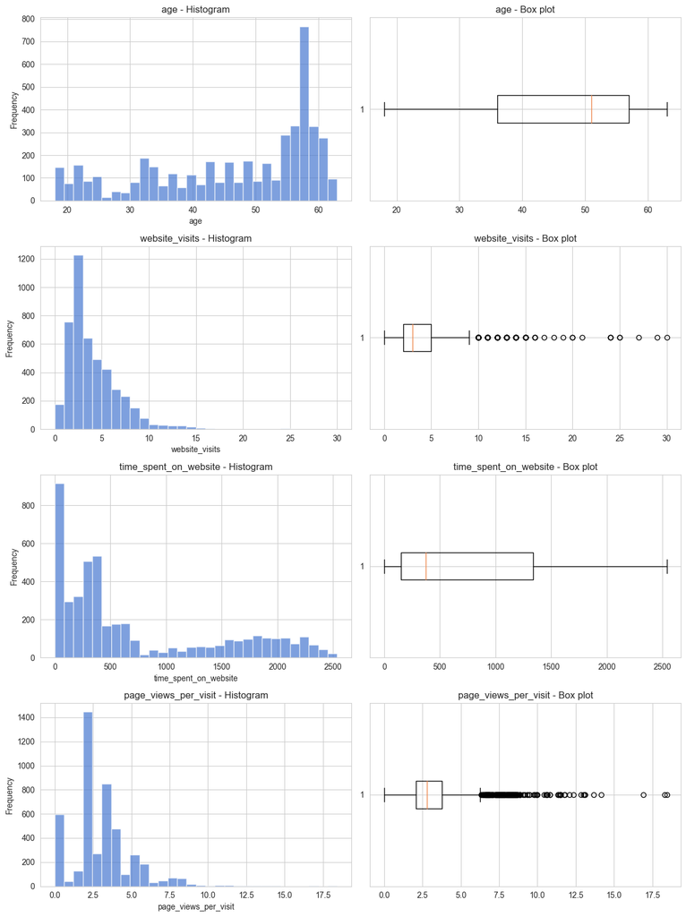

```python
# Set up the figure and axes
fig, axes = plt.subplots(nrows=4, ncols=2, figsize=(12, 16))

# Loop through the numerical variables to plot histograms and box plots
for i, var in enumerate(num_cols):
    # Plot histogram
    axes[i, 0].hist(dt[var], bins=30, alpha=0.7)
    axes[i, 0].set_title(f'{var} - Histogram')
    axes[i, 0].set_xlabel(var)
    axes[i, 0].set_ylabel('Frequency')

    # Plot box plot
    axes[i, 1].boxplot(dt[var], vert=False)
    axes[i, 1].set_title(f'{var} - Box plot')

# Adjust the layout
plt.tight_layout()
plt.show()
```

**Observations:**

- **Age:**

- **Website Visits:**

Histogram: The majority of individuals visited the website a few times, with the frequency decreasing significantly as the number of visits increases. Boxplot: There are several outliers present, indicating that there are individuals who visited the website a significantly higher number of times than the majority.

- **Time Spent on Website:**

- **Page Views per Visit:**

Histogram: The distribution is right-skewed, indicating that most visits involve viewing a small number of pages, with fewer visits involving a large number of page views. Boxplot: There are several outliers present, representing visits with a very high number of page views per visit compared to the majority.

### **Univariate analysis for categorical variables**

```python
# Printing the % sub categories of each category
for i in cat_cols:
    print(dt[i].value_counts(normalize=True))
    print('*'*40)
```

```
Professional    0.567216
Unemployed      0.312446
Student         0.120338
Name: current_occupation, dtype: float64
Website       0.551171
Mobile App    0.448829
Name: first_interaction, dtype: float64
High      0.490893
Medium    0.485906
Low       0.023200
Name: profile_completed, dtype: float64
Email Activity      0.493929
Phone Activity      0.267563
Website Activity    0.238508
Name: last_activity, dtype: float64
No     0.892238
Yes    0.107762
Name: print_media_type1, dtype: float64
No     0.94948
Yes    0.05052
Name: print_media_type2, dtype: float64
No     0.885733
Yes    0.114267
Name: digital_media, dtype: float64
No     0.847138
Yes    0.152862
Name: educational_channels, dtype: float64
No     0.979835
Yes    0.020165
Name: referral, dtype: float64
0    0.701431
1    0.298569
Name: status, dtype: float64
```

**Observations:**

Vizualization of categorical variables:

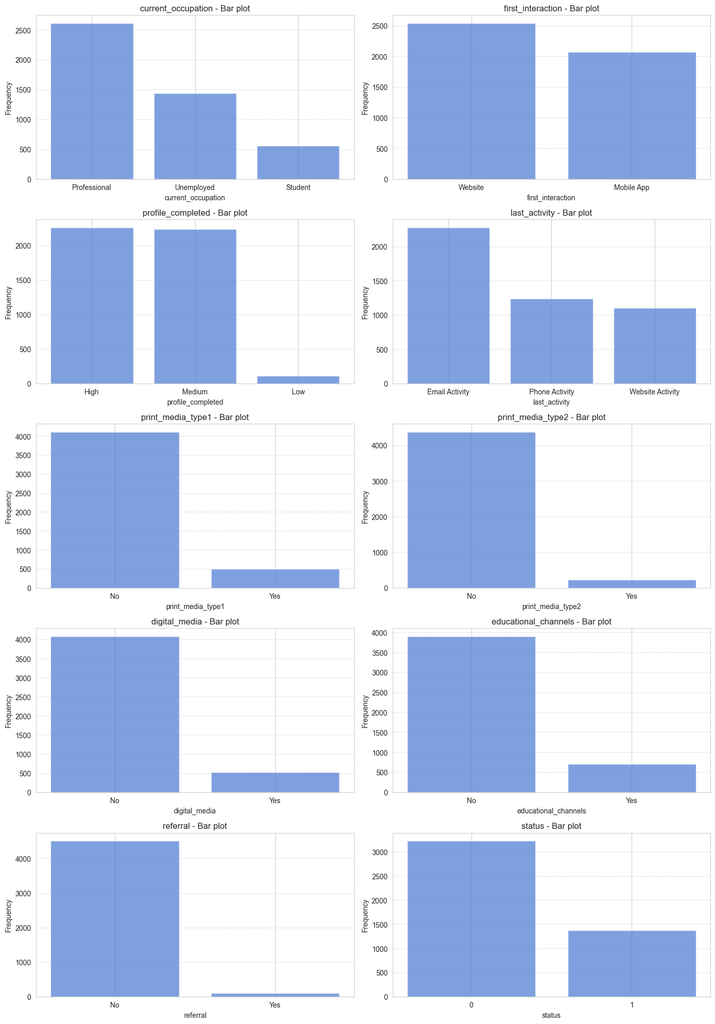

```python
fig, axes = plt.subplots(nrows=5, ncols=2, figsize=(14, 20))

# Loop through the categorical variables to plot bar plots
for i, var in enumerate(cat_cols):
    # Get the value counts of the categorical variable
    value_counts = dt[var].value_counts()

    # Plot bar plot
    axes[i//2, i%2].bar(value_counts.index.astype(str), value_counts.values, alpha=0.7)
    axes[i//2, i%2].set_title(f'{var} - Bar plot')
    axes[i//2, i%2].set_xlabel(var)
    axes[i//2, i%2].set_ylabel('Frequency')
    axes[i//2, i%2].grid(axis='y', linestyle='--', alpha=0.7, linewidth=0.7)

# Adjust the layout
plt.tight_layout()
plt.show()
```

### **Bivariate and Multivariate analysis**

We have analyzed different categorical and numerical variables. Let's now check how does status rate is related with other categorical variables.

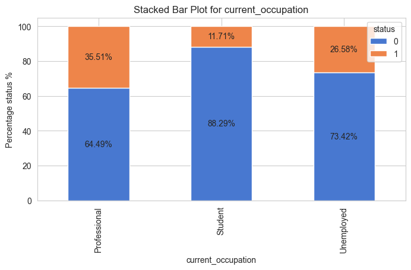

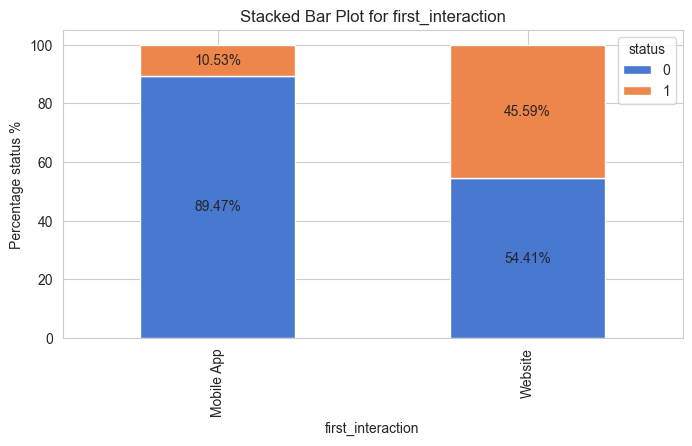

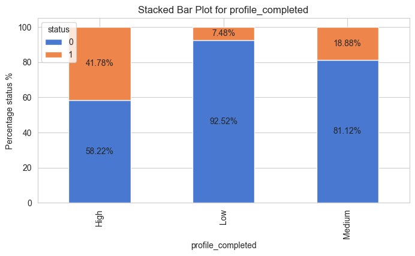

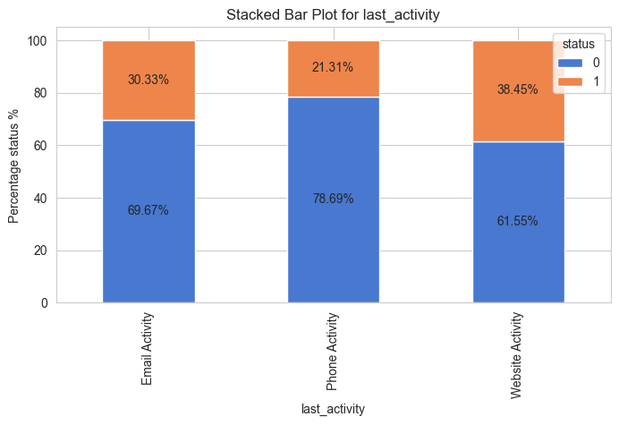

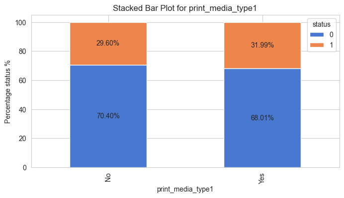

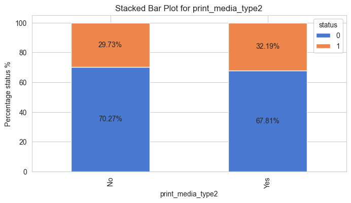

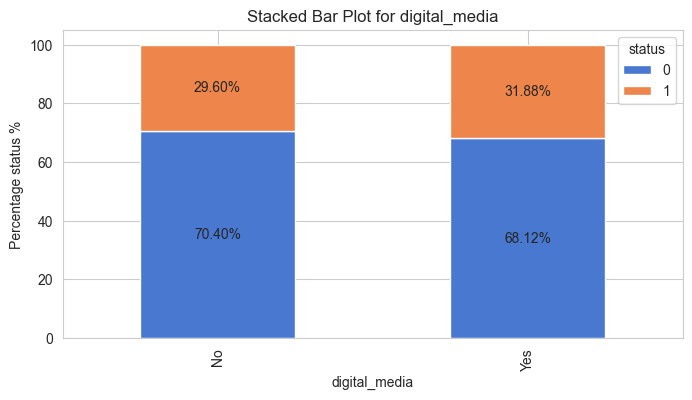

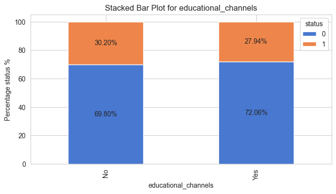

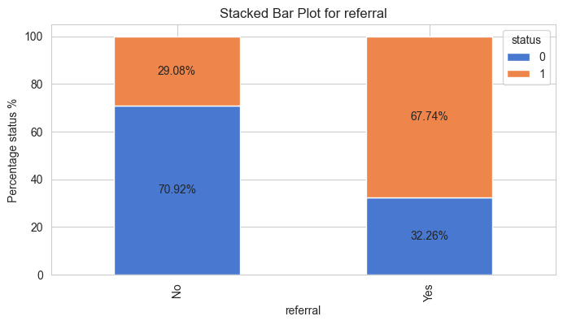

```python
for i in cat_cols:
    if i != 'status':
        # Create a cross-tabulation of the categorical variable with the 'status' variable
        crosstab = (pd.crosstab(dt[i], dt['status'], normalize='index') * 100)

        ax = crosstab.plot(kind='bar', stacked=True, figsize=(8, 4))

        # Add percentage labels on each bar
        for p in ax.patches:
            width, height = p.get_width(), p.get_height()
            x, y = p.get_xy()
            ax.text(x + width/2, y + height/2, f'{height:.2f}%', horizontalalignment='center', verticalalignment='center')

        plt.ylabel('Percentage status %')
        plt.title(f'Stacked Bar Plot for {i}')


        plt.show()
```

**Observation:**

**Let's check the relationship between status and Numerical variables**

```python
# Mean of numerical variables grouped by status
dt.groupby(['status'])[num_cols].mean()
```

| status | age | website_visits | time_spent_on_website | page_views_per_visit |
| --- | --- | --- | --- | --- |
| 0 | 45.153014 | 3.578980 | 577.420711 | 3.025732 |
| 1 | 48.663762 | 3.538126 | 1068.397967 | 3.027050 |

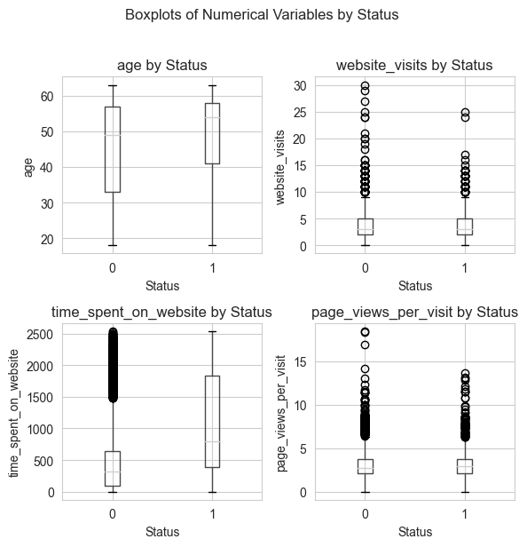

```python
fig, axes = plt.subplots(nrows=2, ncols=2, figsize=(6, 6))

# Loop through the numerical variables to plot box plots
for i, var in enumerate(num_cols):
    # Plot box plot
    dt.boxplot(column=var, by='status', ax=axes[i//2, i%2])
    axes[i//2, i%2].set_title(f'{var} by Status')
    axes[i//2, i%2].set_xlabel('Status')
    axes[i//2, i%2].set_ylabel(var)

# Adjust the layout
plt.tight_layout()
plt.suptitle('Boxplots of Numerical Variables by Status', y=1.02)
plt.show()
```

**Observations:**

**Age:**

The median age is slightly higher for individuals with status 1 compared to those with status 0. There is a considerable overlap in the age distributions between the two groups, indicating that age might not be a strong predictor for status.

**Website Visits:**

The distributions of website visits for both groups (status 0 and 1) are quite similar, with a large number of outliers indicating some individuals have a very high number of visits. The median number of visits is nearly the same for both groups.

**Time Spent on Website:**

Individuals with status 1 tend to spend more time on the website compared to those with status 0, as indicated by a higher median value. The interquartile range is broader for group 1, showing a more substantial dispersion in the time spent on the website.

**Page Views per Visit:**

The distributions of page views per visit are quite similar for both groups, with many outliers indicating some visits involved viewing a high number of pages. The median value is nearly the same for both groups, suggesting that this variable might not strongly differentiate between the two statuses.

### **Let's check the relationship between different variables**

```python
dt.corr()
```

|  | age | website_visits | time_spent_on_website | page_views_per_visit | status |
| --- | --- | --- | --- | --- | --- |
| age | 1.000000 | -0.011975 | 0.018885 | -0.040675 | 0.122084 |
| website_visits | -0.011975 | 1.000000 | 0.062300 | 0.074094 | -0.006609 |
| time_spent_on_website | 0.018885 | 0.062300 | 1.000000 | 0.068130 | 0.302100 |
| page_views_per_visit | -0.040675 | 0.074094 | 0.068130 | 1.000000 | 0.000307 |
| status | 0.122084 | -0.006609 | 0.302100 | 0.000307 | 1.000000 |

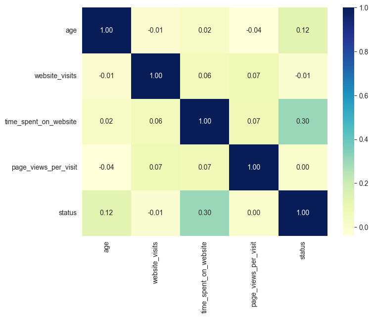

```python
# Plotting the correlation
plt.figure(figsize=(8,6))
sns.heatmap(dt.corr(),annot=True, fmt='0.2f', cmap='YlGnBu');
```

- The "Time Spent on Website" variable has the highest positive correlation with the "Status" variable, indicating that individuals who spend more time on the website are more likely to have a status of 1.
- "Age" also shows a positive correlation with "Status", though to a lesser extent than "Time Spent on Website".
- "Website Visits" and "Page Views per Visit" show virtually no correlation with the "Status" variable, suggesting that they might not be good predictors for the "Status" variable.
- The correlations between the other numerical variables are generally weak, indicating limited linear relationships between them.

## Data Preprocessing

- Missing value treatment (if needed)
- Feature engineering (if needed)
- Outlier detection and treatment (if needed)
- Preparing data for modeling
- Any other preprocessing steps (if needed)

```python
dt.head()
```

|  | age | current_occupation | first_interaction | profile_completed | website_visits | time_spent_on_website | page_views_per_visit | last_activity | print_media_type1 | print_media_type2 | digital_media | educational_channels | referral | status |
| --- | --- | --- | --- | --- | --- | --- | --- | --- | --- | --- | --- | --- | --- | --- |
| 0 | 57 | Unemployed | Website | High | 7 | 1639 | 1.861 | Website Activity | Yes | No | Yes | No | No | 1 |
| 1 | 56 | Professional | Mobile App | Medium | 2 | 83 | 0.320 | Website Activity | No | No | No | Yes | No | 0 |
| 2 | 52 | Professional | Website | Medium | 3 | 330 | 0.074 | Website Activity | No | No | Yes | No | No | 0 |
| 3 | 53 | Unemployed | Website | High | 4 | 464 | 2.057 | Website Activity | No | No | No | No | No | 1 |
| 4 | 23 | Student | Website | High | 4 | 600 | 16.914 | Email Activity | No | No | No | No | No | 0 |

### **Data preparation**

```python
# Creating list of dummy columns
to_get_dummies_for = ['current_occupation', 'first_interaction','profile_completed', 'last_activity']

# Creating dummy variables
dt = pd.get_dummies(data = dt, columns = to_get_dummies_for, drop_first = True)
```

```python
dt.head()
```

|  | age | website_visits | time_spent_on_website | page_views_per_visit | print_media_type1 | print_media_type2 | digital_media | educational_channels | referral | status | current_occupation_Student | current_occupation_Unemployed | first_interaction_Website | profile_completed_Low | profile_completed_Medium | last_activity_Phone Activity | last_activity_Website Activity |
| --- | --- | --- | --- | --- | --- | --- | --- | --- | --- | --- | --- | --- | --- | --- | --- | --- | --- |
| 0 | 57 | 7 | 1639 | 1.861 | Yes | No | Yes | No | No | 1 | 0 | 1 | 1 | 0 | 0 | 0 | 1 |
| 1 | 56 | 2 | 83 | 0.320 | No | No | No | Yes | No | 0 | 0 | 0 | 0 | 0 | 1 | 0 | 1 |
| 2 | 52 | 3 | 330 | 0.074 | No | No | Yes | No | No | 0 | 0 | 0 | 1 | 0 | 1 | 0 | 1 |
| 3 | 53 | 4 | 464 | 2.057 | No | No | No | No | No | 1 | 0 | 1 | 1 | 0 | 0 | 0 | 1 |
| 4 | 23 | 4 | 600 | 16.914 | No | No | No | No | No | 0 | 1 | 0 | 1 | 0 | 0 | 0 | 0 |

```python
# Mapping overtime and attrition
dict_print_media_type1 = {'Yes': 1, 'No':0}
dict_print_media_type2 = {'Yes': 1, 'No': 0}
dict_digital_media = {'Yes': 1, 'No':0}
dict_educational_channels = {'Yes': 1, 'No': 0}
dct_referrali = {'Yes': 1, 'No':0}



dt['print_media_type1'] = dt.print_media_type1.map(dict_print_media_type1)
dt['print_media_type2'] = dt.print_media_type2.map(dict_print_media_type2)
dt['digital_media'] = dt.digital_media.map(dict_digital_media)
dt['educational_channels'] = dt.educational_channels.map(dict_educational_channels)
dt['referral'] = dt.referral.map(dct_referrali)
```

```python
dt.head()
```

|  | age | website_visits | time_spent_on_website | page_views_per_visit | print_media_type1 | print_media_type2 | digital_media | educational_channels | referral | status | current_occupation_Student | current_occupation_Unemployed | first_interaction_Website | profile_completed_Low | profile_completed_Medium | last_activity_Phone Activity | last_activity_Website Activity |
| --- | --- | --- | --- | --- | --- | --- | --- | --- | --- | --- | --- | --- | --- | --- | --- | --- | --- |
| 0 | 57 | 7 | 1639 | 1.861 | 1 | 0 | 1 | 0 | 0 | 1 | 0 | 1 | 1 | 0 | 0 | 0 | 1 |
| 1 | 56 | 2 | 83 | 0.320 | 0 | 0 | 0 | 1 | 0 | 0 | 0 | 0 | 0 | 0 | 1 | 0 | 1 |
| 2 | 52 | 3 | 330 | 0.074 | 0 | 0 | 1 | 0 | 0 | 0 | 0 | 0 | 1 | 0 | 1 | 0 | 1 |
| 3 | 53 | 4 | 464 | 2.057 | 0 | 0 | 0 | 0 | 0 | 1 | 0 | 1 | 1 | 0 | 0 | 0 | 1 |
| 4 | 23 | 4 | 600 | 16.914 | 0 | 0 | 0 | 0 | 0 | 0 | 1 | 0 | 1 | 0 | 0 | 0 | 0 |

**Separating the independent variables (X) and the dependent variable (Y)**

```python
# Separating target variable and other variables

Y= dt.status
X= dt.drop(columns = ['status'])
```

**Splitting the data into 70% train and 30% test set**

Some classification problems can exhibit a large imbalance in the distribution of the target classes: for instance there could be several times more negative samples than positive samples. In such cases it is recommended to use the **stratified sampling** technique to ensure that relative class frequencies are approximately preserved in each train and validation fold.

```python
# Splitting the data
X_train, X_test, y_train, y_test = train_test_split(X, Y, test_size = 0.3, random_state = 1, stratify = Y)
```

### **Scaling the data**

```python
# Scaling the data
sc=StandardScaler()

# Fit_transform on train data
X_train_scaled=sc.fit_transform(X_train)
X_train_scaled=pd.DataFrame(X_train_scaled, columns=X.columns)

# Transform on test data
X_test_scaled=sc.transform(X_test)
X_test_scaled=pd.DataFrame(X_test_scaled, columns=X.columns)
```

### **Model evaluation criterion**

**The model can make two types of wrong predictions:** Flag indicating whether the lead was converted to a paid customer or not.

1. Predicting a lead will indicate as a paid customer when the lead doesn't paid customer
2. Predicting a lead will **not indicate** as a paid customer when the lead acrualy is paid customer

**Which case is more important?**

- **Predicting a lead will not indicate as a paid customer when the lead acrualy is paid customer**. The type of error is FN.

```python
# Function to print the classification report and get confusion matrix in a proper format

def metrics_score(actual, predicted):
    print(classification_report(actual, predicted))

    cm = confusion_matrix(actual, predicted)

    plt.figure(figsize = (8, 5))

    sns.heatmap(cm, annot = True,  fmt = '.2f', xticklabels = ['Not Converted', 'Converted'], yticklabels = ['Not Converted', 'Converted'])

    plt.ylabel('Actual')

    plt.xlabel('Predicted')

    plt.show()
```

## Building a Decision Tree model

```python
dt_classifier = DecisionTreeClassifier(random_state=42)
dt_classifier.fit(X_train_scaled, y_train)
```

```
DecisionTreeClassifier(random_state=42)
```

**Let's check the model performance of decision tree**

```
              precision    recall  f1-score   support

           0       0.85      0.86      0.86       971
           1       0.67      0.64      0.66       413

    accuracy                           0.80      1384
   macro avg       0.76      0.75      0.76      1384
weighted avg       0.80      0.80      0.80      1384
```

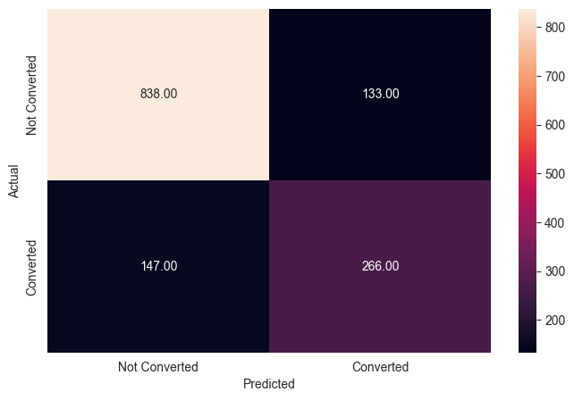

```python
# Checking performance on the test dataset
y_test_pred_dt = dt_classifier.predict(X_test_scaled)
score = metrics_score(y_test, y_test_pred_dt)
```

```
              precision    recall  f1-score   support

           0       1.00      1.00      1.00      2264
           1       1.00      1.00      1.00       964

    accuracy                           1.00      3228
   macro avg       1.00      1.00      1.00      3228
weighted avg       1.00      1.00      1.00      3228
```

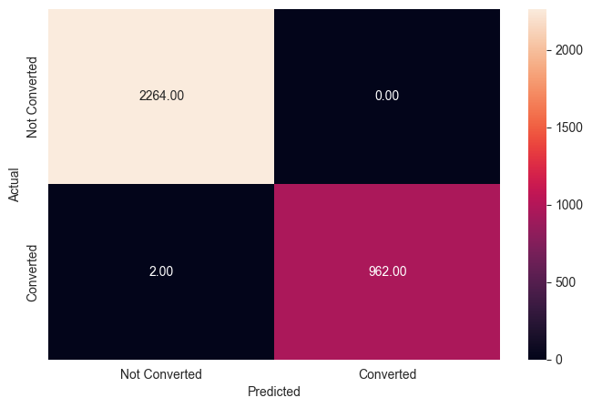

```python
# Checking performance on the training dataset
y_train_pred_dt = dt_classifier.predict(X_train_scaled)
score = metrics_score(y_train, y_train_pred_dt)
```

**Observations:**

- The **Decision tree** classifier **seems to be overfitting the training data**. The recall on the training data is 1, while the recall on the test data is only ~ 0.86 for class 0.
- Precision is high for the test data as well.

**Let's plot the feature importance and check the most important features.**

```python
# Importance of features in the tree building

Imp_f_d_tree = pd.DataFrame(dt_classifier.feature_importances_, columns = ["Imp"], index = X_train.columns).sort_values(by = 'Imp', ascending = False)
Imp_f_d_tree
```

|  | Imp |
| --- | --- |
| time_spent_on_website | 0.271434 |
| first_interaction_Website | 0.144650 |
| page_views_per_visit | 0.126737 |
| profile_completed_Medium | 0.122350 |
| age | 0.114065 |
| website_visits | 0.057726 |
| current_occupation_Unemployed | 0.042872 |
| last_activity_Phone Activity | 0.040549 |
| last_activity_Website Activity | 0.027046 |
| profile_completed_Low | 0.018771 |
| print_media_type1 | 0.007254 |
| print_media_type2 | 0.006648 |
| digital_media | 0.006203 |
| educational_channels | 0.005895 |
| referral | 0.005875 |
| current_occupation_Student | 0.001926 |

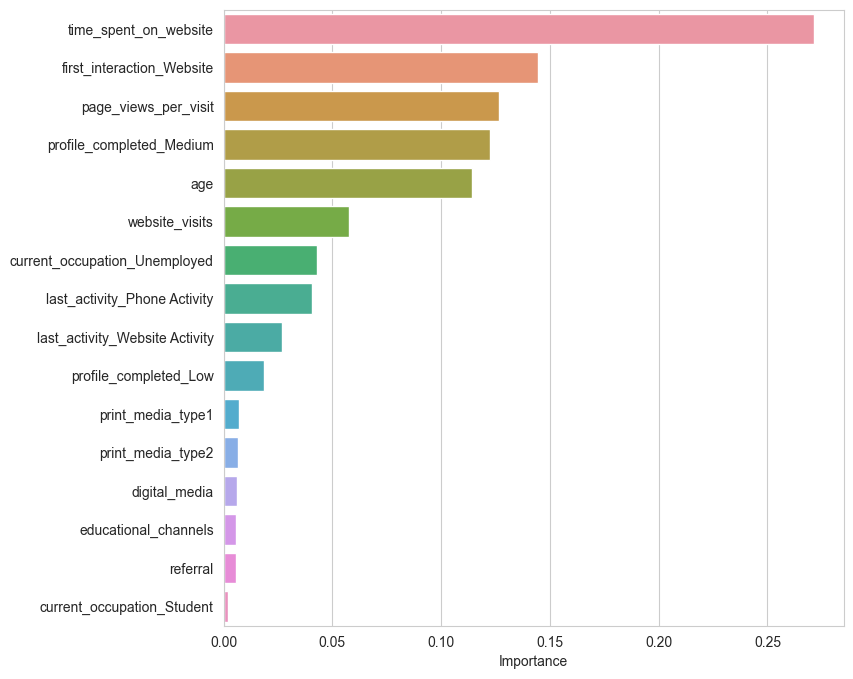

```python
# Plot the feature importance

importances = dt_classifier.feature_importances_
columns = X.columns
importance_df = pd.DataFrame(importances, index = columns, columns = ['Importance']).sort_values(by = 'Importance', ascending = False)
plt.figure(figsize = (8, 8))
sns.barplot(data = importance_df, x = importance_df.Importance, y = importance_df.index);
```

### Visualizing the Decision Tree

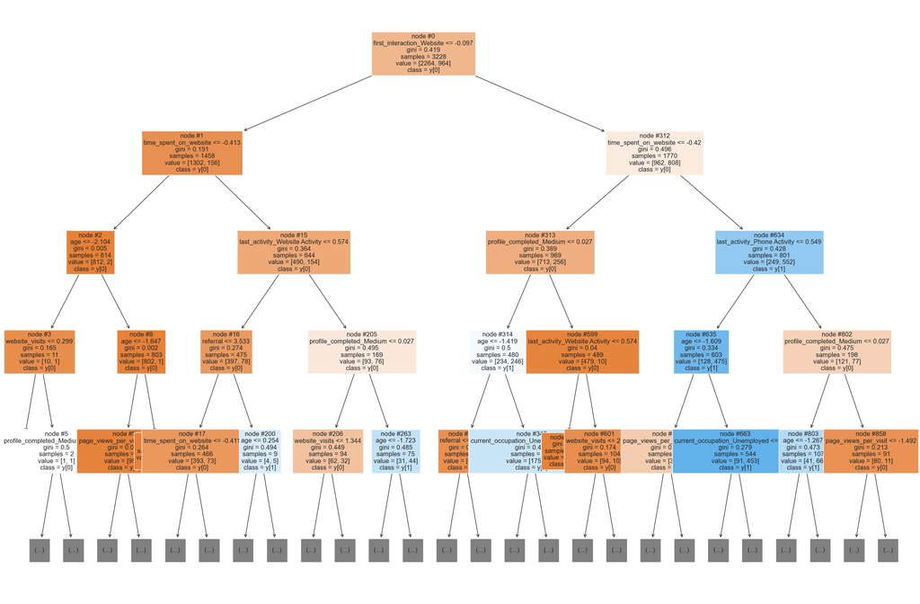

```python
features = list(X.columns)

plt.figure(figsize = (30, 20))

tree.plot_tree(dt_classifier, max_depth = 4, feature_names = features, filled = True, fontsize = 12, node_ids = True, class_names = True)

plt.show()
```

**Note:** Blue leaves represent the converted leads, i.e., **y[1]**, while the orange leaves represent the not converted leads, i.e., **y[0]**. Also, the more the number of observations in a leaf, the darker its color gets.

**Observation**: Complex Tree Structure with Many Nodes. The decision tree has grown to have many nodes, creating a very complex and intricate structure. This suggests that the model is capturing noise in the training set, which doesn't generalize well to unseen data.

## Do we need to prune the tree?

```python
# Choose the type of classifier
d_tree_tuned = DecisionTreeClassifier(random_state = 7, class_weight = {0: 0.3, 1: 0.7})

# Grid of parameters to choose from
parameters = {'max_depth': np.arange(2, 10),
              'criterion': ['gini', 'entropy'],
              'min_samples_leaf': [5, 10, 20, 25]
             }

# Type of scoring used to compare parameter combinations - recall score for class 1
scorer = metrics.make_scorer(recall_score, pos_label = 1)

# Run the grid search
grid_obj = GridSearchCV(d_tree_tuned, parameters, scoring = scorer, cv = 5)

grid_obj = grid_obj.fit(X_train_scaled, y_train)

# Set the classifier to the best combination of parameters
d_tree_tuned = grid_obj.best_estimator_

# Fit the best algorithm to the data
d_tree_tuned.fit(X_train_scaled, y_train)
```

```
DecisionTreeClassifier(class_weight={0: 0.3, 1: 0.7}, criterion='entropy',
                       max_depth=3, min_samples_leaf=5, random_state=7)
```

**Let's check the model performance on the training and testing data.**

```
              precision    recall  f1-score   support

           0       0.95      0.75      0.84      2264
           1       0.60      0.91      0.72       964

    accuracy                           0.79      3228
   macro avg       0.78      0.83      0.78      3228
weighted avg       0.85      0.79      0.80      3228
```

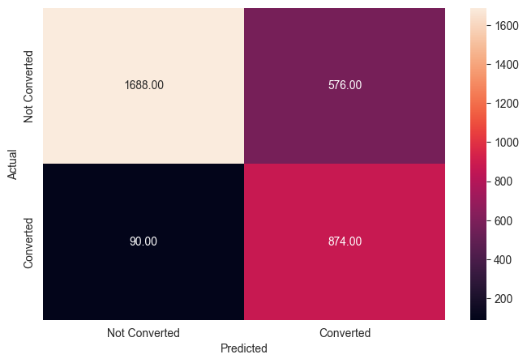

```python
# Checking performance on the training data

y_train_pred_dt2 = d_tree_tuned.predict(X_train_scaled)

score_train = metrics_score(y_train, y_train_pred_dt2)
```

```
              precision    recall  f1-score   support

           0       0.94      0.73      0.82       971
           1       0.58      0.89      0.70       413

    accuracy                           0.78      1384
   macro avg       0.76      0.81      0.76      1384
weighted avg       0.83      0.78      0.79      1384
```

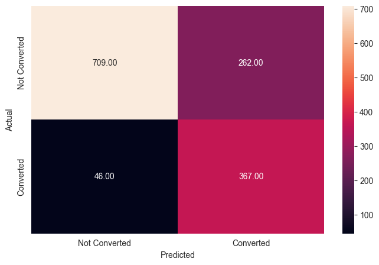

```python
# Checking performance on the testing data

y_test_pred_dt2 = d_tree_tuned.predict(X_test_scaled)

score_test = metrics_score(y_test, y_test_pred_dt2)
```

**Overall Observations**

- Improved Recall for Class 1: The tuning and class weight adjustments have successfully increased the recall for class 1, meaning the model is identifying a higher proportion of the actual "Converted" cases.
- Decreased Precision for Class 1: While the recall for class 1 has improved, it has come at the cost of a reduced precision, meaning the model is now predicting more false positives for class 1.
- Room for Further Optimization: Although the model's performance has improved in identifying the "Converted" cases, there is still room to optimize the model to reduce the number of false positives without significantly compromising the recall.

**Let's visualize the tuned decision tree** and observe the decision rules:

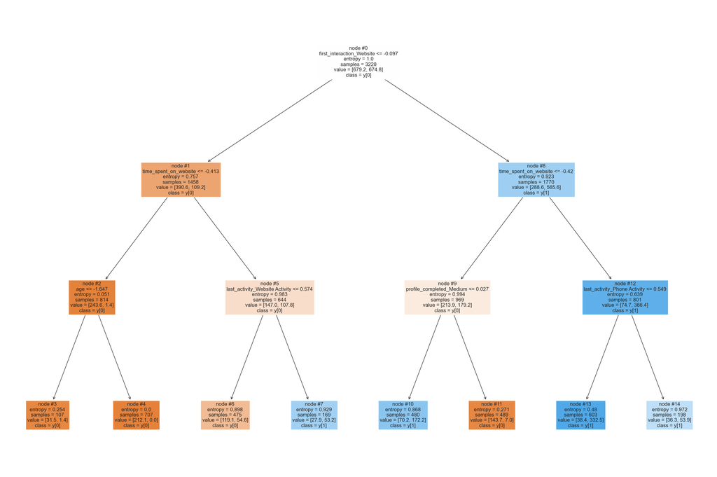

```python
features = list(X.columns)

plt.figure(figsize = (30, 20))

tree.plot_tree(d_tree_tuned, max_depth = 4, feature_names = features, filled = True, fontsize = 12, node_ids = True, class_names = True)

plt.show()
```

**Note:** Blue leaves represent the converted leads, i.e., **y[1]**, while the orange leaves represent the not converted leads, i.e., **y[0]**. Also, the more the number of observations in a leaf, the darker its color gets.

**Observations:**

The first split in the decision tree is at the first interaction of the website which implies that it is one of the most important factors in deciding whether the lead will be converted or not. As per decision rules, leads who spent more time on the website, are more likely to convert. The leads whose age was greater than 25 are more likely to convert to paid customers. Leads that spent less time on the website and were younger than 25 were more like to not covert to a paid customer.

**Let's look at the feature importance** of the tuned decision tree model

```python
# Importance of features in the tree building

Imp_f_d_tuned = pd.DataFrame(d_tree_tuned.feature_importances_, columns = ["Imp"], index = X_train.columns).sort_values(by = 'Imp', ascending = False)
Imp_f_d_tuned
```

|  | Imp |
| --- | --- |
| time_spent_on_website | 0.365546 |
| first_interaction_Website | 0.313484 |
| profile_completed_Medium | 0.233702 |
| last_activity_Phone Activity | 0.048402 |
| last_activity_Website Activity | 0.032013 |
| age | 0.006853 |
| website_visits | 0.000000 |
| page_views_per_visit | 0.000000 |
| print_media_type1 | 0.000000 |
| print_media_type2 | 0.000000 |
| digital_media | 0.000000 |
| educational_channels | 0.000000 |
| referral | 0.000000 |
| current_occupation_Student | 0.000000 |
| current_occupation_Unemployed | 0.000000 |
| profile_completed_Low | 0.000000 |

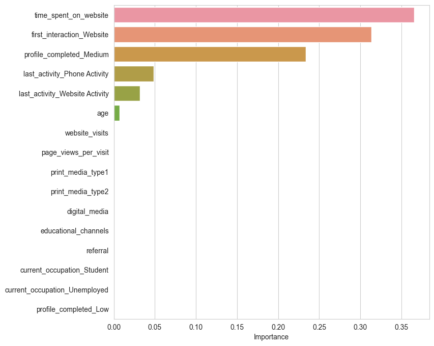

```python
# Plot the feature importance

importances = d_tree_tuned.feature_importances_
columns = X.columns
importance_df = pd.DataFrame(importances, index = columns, columns = ['Importance']).sort_values(by = 'Importance', ascending = False)
plt.figure(figsize = (8, 8))
sns.barplot(data = importance_df, x = importance_df.Importance, y = importance_df.index);
```

**Observations:**

- After tuning the model, we found out that only 3 features are important. It seems like **the model is having high bias**, as it has over-simplified the problem and is not capturing the patterns associated with other variables.
- **Highly Important Features**
1. **Time Spent on Website (36.55%)**: This feature stands as the most significant predictor in the model, implying that the duration a lead spends on the website has a substantial influence on their conversion probability.
2. **First Interaction - Website (31.35%)**: The initial interaction happening through the website is the second most influential feature, highlighting the pivotal role of the website in the lead conversion process.
3. **Profile Completed - Medium (23.37%)**: Leads having a medium level of profile completion significantly affect the conversion rate, indicating the importance of encouraging leads to complete their profiles to a medium level.
- **Negligible Importance Features**

The following features have zero importance in the current decision tree model, indicating they do not contribute to the decision-making process in the existing model setup:

- Website Visits
- Page Views per Visit
- Print Media Type1 and Type2
- Digital Media
- Educational Channels
- Referral
- Current Occupation (both Student and Unemployed categories)
- Profile Completed - Low

**Recommendations**

**Focus on Highly Important Features**: Marketing strategies should focus more on enhancing the user experience on the website to increase the time spent on the website and encourage leads to complete their profiles to at least a medium level.

## Building a Random Forest model

```python
#Create an instance of the RandomForestClassifier
rf_estimator = RandomForestClassifier(random_state=42, n_estimators=100)

#Fit the model on the training data
rf_estimator.fit(X_train_scaled, y_train)
```

```
RandomForestClassifier(random_state=42)
```

```python
# Making predictions on the test data
y_test_pred_rf = rf_estimator.predict(X_test_scaled)
```

**Let's check the performance of the model on the training data**

```
              precision    recall  f1-score   support

           0       1.00      1.00      1.00      2264
           1       1.00      1.00      1.00       964

    accuracy                           1.00      3228
   macro avg       1.00      1.00      1.00      3228
weighted avg       1.00      1.00      1.00      3228
```

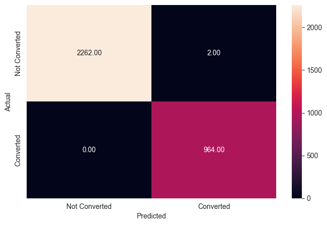

```python
#Predicting the training data labels
y_pred_train3 = rf_estimator.predict(X_train_scaled)

score_train_rf = metrics_score(y_train, y_pred_train3)
```

**Observations:**

- High Performance on Training Data: The Random Forest model is exhibiting high performance on the training data, correctly predicting nearly every instance.
- Potential Overfitting: While high performance on the training data is generally a good sign, performance metrics nearing perfection could also be an indication of potential overfitting to the training data. Overfitting occurs when the model learns the noise in the training data, resulting in poor generalization to new, unseen data.

**Let's check the performance of the model on the test data**

```
              precision    recall  f1-score   support

           0       0.89      0.91      0.90       971
           1       0.77      0.74      0.75       413

    accuracy                           0.86      1384
   macro avg       0.83      0.82      0.83      1384
weighted avg       0.85      0.86      0.86      1384
```

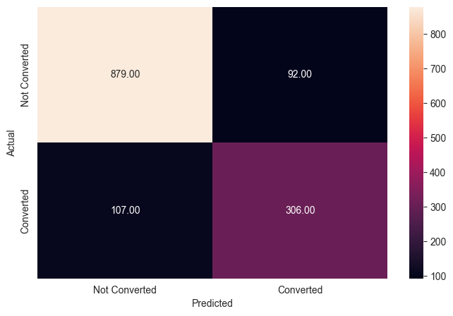

```python
#Predicting the test data labels
y_pred_test3 = rf_estimator.predict(X_test_scaled)

score_test_rf = metrics_score(y_test, y_pred_test3)
```

**Observations:**

- Good Generalization: The model generalizes well to unseen data, evidenced by a high accuracy of 86% on the test set. This is a good indication that the model is not just memorizing the training data but learning underlying patterns in the data.
- Balanced Performance Across Classes: The model exhibits balanced performance across both classes, with good precision and recall values for both classes, although it performs slightly better for class 0 (Not Converted).
- Slightly Overfitted: Comparing training and test results, it seems the model might be slightly overfitting to the training data, as indicated by the drop in performance metrics from training to test datasets. However, the high test accuracy still indicates a reasonably robust model.

### **Random Forest Classifier - Hyperparameter Tuning**

```python
# Choose the type of classifier
rf_estimator_tuned = RandomForestClassifier(criterion = "entropy", random_state = 7)

# Grid of parameters to choose from
parameters = {
    "n_estimators": [110, 120],
    "max_depth": [6, 7],
    "min_samples_leaf": [20, 25],
    "max_features": [0.8, 0.9],
    "max_samples": [0.9, 1],
    "class_weight": ["balanced", {0: 0.3, 1: 0.7}]
}

# Type of scoring used to compare parameter combinations
scorer = metrics.make_scorer(recall_score, pos_label = 1)

# Run the grid search on the training data
grid_obj = GridSearchCV(rf_estimator_tuned, parameters, scoring=scorer, cv=5)
grid_obj = grid_obj.fit(X_train_scaled, y_train)

# Save the best estimator to variable rf_estimator_tuned
rf_estimator_tuned = grid_obj.best_estimator_

# Display the best parameters found by the grid search
print('Best parameters found: ', grid_obj.best_params_)
```

```
Best parameters found:  {'class_weight': 'balanced', 'max_depth': 6, 'max_features': 0.8, 'max_samples': 0.9, 'min_samples_leaf': 25, 'n_estimators': 110}
```

```python
rf_estimator_tuned.fit(X_train_scaled, y_train)
```

```
RandomForestClassifier(class_weight='balanced', criterion='entropy',
                       max_depth=6, max_features=0.8, max_samples=0.9,
                       min_samples_leaf=25, n_estimators=110, random_state=7)
```

**Let's check the performance of the model on the training data**

```
              precision    recall  f1-score   support

           0       0.94      0.82      0.88      2264
           1       0.67      0.89      0.77       964

    accuracy                           0.84      3228
   macro avg       0.81      0.85      0.82      3228
weighted avg       0.86      0.84      0.84      3228
```

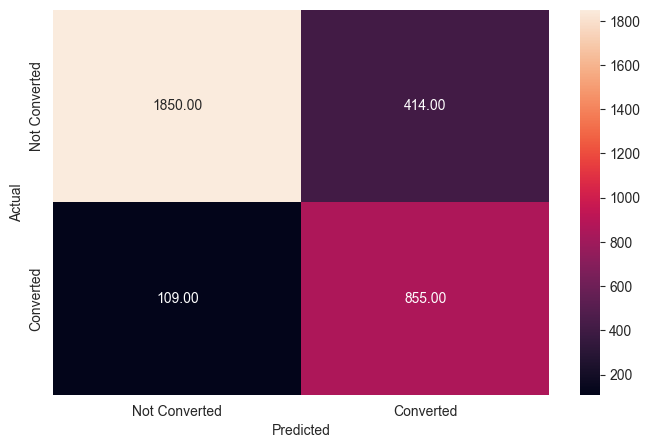

```python
# Checking performance on the training data

y_pred_train_rft = rf_estimator_tuned.predict(X_train_scaled)

score_train_rft = metrics_score(y_train, y_pred_train_rft)
```

**Observations:**

**Let's check the performance of the model on the test data**

```
              precision    recall  f1-score   support

           0       0.93      0.81      0.86       971
           1       0.65      0.85      0.74       413

    accuracy                           0.82      1384
   macro avg       0.79      0.83      0.80      1384
weighted avg       0.85      0.82      0.83      1384
```

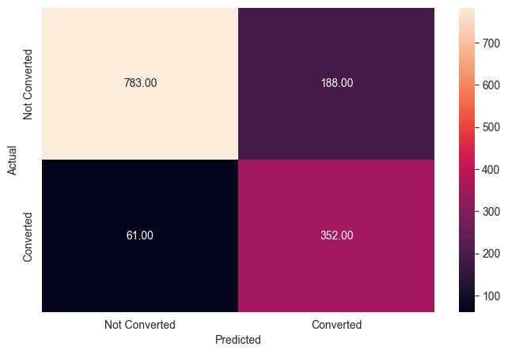

```python
# Checking performance on the test data

y_pred_test_rft = rf_estimator_tuned.predict(X_test_scaled)

score_test_rft = metrics_score(y_test, y_pred_test_rft)
```

**Observations:**

```python
# Importance of features in the tree building

Imp_f_fr_tuned = pd.DataFrame(rf_estimator_tuned.feature_importances_, columns = ["Imp"], index = X_train.columns).sort_values(by = 'Imp', ascending = False)
Imp_f_fr_tuned
```

|  | Imp |
| --- | --- |
| time_spent_on_website | 0.308928 |
| first_interaction_Website | 0.277740 |
| profile_completed_Medium | 0.192688 |
| age | 0.054356 |
| last_activity_Website Activity | 0.045612 |
| last_activity_Phone Activity | 0.043320 |
| current_occupation_Unemployed | 0.034854 |
| page_views_per_visit | 0.017036 |
| current_occupation_Student | 0.015427 |
| website_visits | 0.006927 |
| profile_completed_Low | 0.001680 |
| educational_channels | 0.001171 |
| digital_media | 0.000173 |
| print_media_type1 | 0.000087 |
| print_media_type2 | 0.000000 |
| referral | 0.000000 |

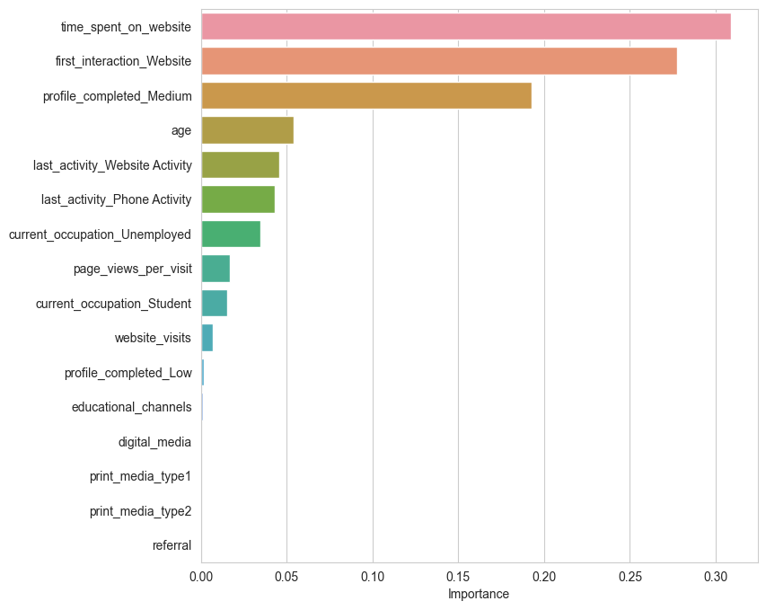

```python
importances = rf_estimator_tuned.feature_importances_
columns = X.columns
importance_df = pd.DataFrame(importances, index = columns, columns = ['Importance']).sort_values(by = 'Importance', ascending = False)
plt.figure(figsize = (8, 8))
sns.barplot(data = importance_df, x = importance_df.Importance, y = importance_df.index);
```

**Observations:**

## Actionable Insights and Recommendations

### **Business Recommendations:**

- **Website Enhancement:** *User Engagement:* Allocate resources to augment the website’s UX/UI, encouraging leads to spend more time exploring the available content. *Content Enrichment:* Fortify the website with enriching and interactive content to captivate leads right from their initial interaction.
- **Profile Completion:** *Incentives for Profile Completion:* Propagate a culture where leads are incentivized, possibly with discounts, to complete their profiles, fostering a higher conversion likelihood. *Personalized Campaigns:* Craft marketing campaigns that resonate with the leads' preferences and needs, leveraging data from their completed profiles.
- **Targeted Marketing for Older Demographics:** *Tailored Offerings:* Develop and promote courses or offerings that cater specifically to older adults, attracting more such leads with a higher conversion propensity. *Feedback Mechanism:* Instill a system to continually garner feedback from leads, facilitating a deeper understanding of their requirements and preferences, and aligning services accordingly.

### **Final Note:**

Utilizing the insights derived from the tuned random forest model, ExtraaLearn can strategically pinpoint the potential leads more likely to convert. This approach will not only economize the marketing efforts but will significantly bolster the lead conversion rate, steering the business towards a path of sustained growth and success. It is recommended to remain adaptive and receptive to the dynamically changing preferences and behaviors of the leads, constantly fine-tuning the strategies to retain a competitive edge in the evolving EdTech market landscape.